# Introduction to species distribution modelling (SDM) in R

Damaris Zurell

https://damariszurell.github.io  
Biodiversity Modelling Lab  
Geography Department  
Humboldt-Universität zu Berlin

damaris@zurell.de

6 September 2019

# 1 Background

Here, I provide a short, half-day introduction to species distribution modelling in R. The course gives a brief overview of the concept of species distribution modelling, and introduces the main modelling steps. Codes and data largely follow the materials from Zurell and Engler (2019).

Species distribution models (SDMs) are a popular tool in quantitative ecology (Franklin 2010; Guisan, Thuiller, and Zimmermann 2017) and constitute the most widely used modelling framework in global change impact assessments for projecting potential future range shifts of species (IPBES 2016). There are several reasons that make them so popular: they are comparably easy to use because many software packages (e.g. Thuiller et al. 2009; Phillips, Anderson, and Schapire 2006) and guidelines (e.g. Elith, Leathwick, and Hastie 2008; Elith et al. 2011; Merow, Smith, and Silander Jr 2013; Guisan, Thuiller, and Zimmermann 2017) are available, and they have comparably low data requirements.

As input, SDMs require georeferenced biodiversity observations (e.g. individual locations, species’ presence, species’ counts, species richness; the response or dependent variable) and geographic layers of environmental information (e.g. climate, land cover, soil attributes; the predictor or independent variables). Such information are now widely available in digital format. For example, online repositories provide data on species distributions (e.g. GBIF and [OBIS](https://obis.org/)), on individual animal locations (e.g. Movebank), on climate (e.g. [WorldClim](http://www.worldclim.org/) and [CHELSA](http://chelsa-climate.org/)) as well as land cover and other remote sensing products (e.g. [Copernicus](https://land.copernicus.eu/global/products)). We can then relate the biodiversity observations at specific sites to the prevailing environmental conditions at those sites. Different statistical and machine-learning algorithms are available for this. Once we have estimated this biodiversity-environment relationship, we can make predictions in space and in time by projecting the model onto available environmental layers (Figure 1.1).

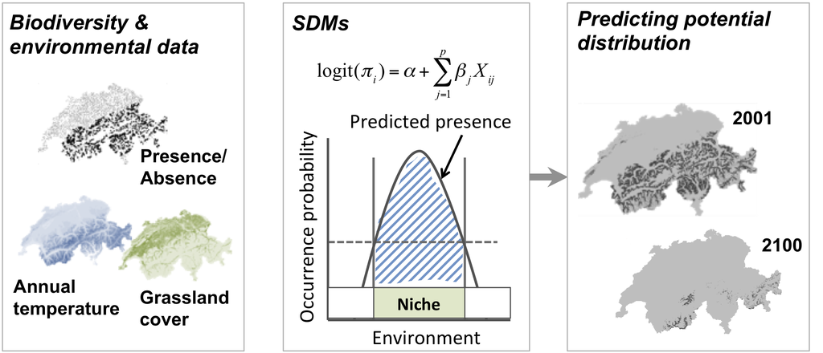

Figure 1.1: Schematic representation of species distribution modelling concept.

# References

Elith, Jane, Steven J. Phillips, Trevor Hastie, Miroslav Dudik, Yung En Chee, and Colin J. Yates. 2011. “A Statistical Explanation of Maxent for Ecologists.” *Diversity and Distributions* 17: 43–57.

Elith, J., J. R. Leathwick, and T. Hastie. 2008. “A Working Guide to Boosted Regression Trees.” *Journal of Animal Ecology* 77: 802–13.

Franklin, Janet. 2010. *Mapping Species Distributions: Spatial Inference and Prediction*. Cambride University Press.

Guisan, Antoine, Wilfried Thuiller, and Niklaus E. Zimmermann. 2017. *Habitat Suitability and Distribution Models with Applications in R*. Cambride University Press.

IPBES. 2016. *The Methodological Assessment Report on Scenarios and Models of Biodiversity and Ecosystem Services*. Edited by S. Ferrier, K. N. Ninan, P. Leadley, R. Alkemade, L. A. Acosta, H. R. Akcakaya, L. Brotons, et al. Secretariat of the Intergovernmental Science-Policy Platform on Biodiversity; Ecosystem Services, Bonn, Germany.

Merow, Cory, Matthew J. Smith, and John A. Silander Jr. 2013. “A Practical Guide to Maxent for Modeling Species’ Distributions: What It Does, and Why Inputs and Settings Matter.” *Ecography* 36: 1058–69.

Phillips, Steven J., Robert P. Anderson, and Robert E. Schapire. 2006. “Maximum Entropy Modeling of Species Geographic Distributions.” *Ecological Modelling* 190: 231–59.

Thuiller, Wilfried, Bruno Lafourcade, Robin Engler, and Miguel B. Araujo. 2009. “BIOMOD - a Platform for Ensemble Forecasting of Species Distributions.” *Ecography* 32: 369–73.

Zurell, D., and J.O. Engler. 2019. “Effects of Climate Change on Birds.” In, edited by P.O. Dunn and A.P. Moller, 60–73. Oxford University Press.